# skeleton of 715 project

2023-12-09

Author: Avon Yang, Nuoya Jiang

## R Markdown

8 independent variable: “RIDAGEYR”, “RIAGENDR”, “INDFMIN2”,“LBXSKSI”, “LBXSCH”, “LBXSTP”, “LBXSGL”, “LBXSNASI”,“BMXBMI” Demographic: age, gender, income, Lab tests: blood potassium, cholesterol,protein, glucose, and sodium Goal: Classification of overweight individuals from non-overweight individuals

Rubric 2: EDA and QC of data

```r
subset_df <- read.csv("nhanes_13_14_subset.csv")

#age, gender, income, potassium, cholesterol, protein, serum glucose, blood sodium, bmi
data <- subset_df[, c("RIDAGEYR", "RIAGENDR", "INDFMIN2","LBXSKSI", "LBXSCH", "LBXSTP", "LBXSGL", "LBXSNASI","BMXBMI")]
#inspect if we have NA values
any_na <- any(is.na(data))
print(paste("Are there any NA values in the data frame? ", any_na))
```

```
## [1] "Are there any NA values in the data frame?  TRUE"
```

```r
#inspect num/cat.
str(data)
```

```
## 'data.frame':    10175 obs. of  9 variables:
##  $ RIDAGEYR: int  69 54 72 9 73 56 0 61 56 65 ...
##  $ RIAGENDR: int  1 1 1 1 2 1 1 2 2 1 ...
##  $ INDFMIN2: int  4 7 10 9 15 9 15 10 4 3 ...
##  $ LBXSKSI : num  4.3 4.3 4.2 NA 4.1 3.3 NA 3.9 4 4.8 ...
##  $ LBXSCH  : int  168 167 127 NA 207 230 NA 167 278 170 ...
##  $ LBXSTP  : num  6.5 7.8 5.9 NA 7.1 7.3 NA 6.4 6.6 7.5 ...
##  $ LBXSGL  : int  554 219 183 NA 104 104 NA 107 108 104 ...
##  $ LBXSNASI: int  136 128 142 NA 142 143 NA 140 139 140 ...
##  $ BMXBMI  : num  26.7 28.6 28.9 17.1 19.7 41.7 NA 35.7 26.5 22 ...
```

```r
# Summary statistics for numeric columns
summary(data)
```

```
##     RIDAGEYR        RIAGENDR        INDFMIN2        LBXSKSI
##  Min.   : 0.00   Min.   :1.000   Min.   : 1.00   Min.   :2.800
##  1st Qu.:10.00   1st Qu.:1.000   1st Qu.: 5.00   1st Qu.:3.800
##  Median :26.00   Median :2.000   Median : 7.00   Median :4.000
##  Mean   :31.48   Mean   :1.508   Mean   :10.51   Mean   :4.027
##  3rd Qu.:52.00   3rd Qu.:2.000   3rd Qu.:14.00   3rd Qu.:4.200
##  Max.   :80.00   Max.   :2.000   Max.   :99.00   Max.   :5.800
##                                  NA's   :123     NA's   :3623
##      LBXSCH          LBXSTP           LBXSGL         LBXSNASI
##  Min.   : 72.0   Min.   : 4.700   Min.   : 49.0   Min.   :119.0
##  1st Qu.:155.0   1st Qu.: 6.800   1st Qu.: 86.0   1st Qu.:139.0
##  Median :181.0   Median : 7.100   Median : 93.0   Median :140.0
##  Mean   :184.5   Mean   : 7.108   Mean   :102.3   Mean   :139.8
##  3rd Qu.:210.0   3rd Qu.: 7.400   3rd Qu.:104.0   3rd Qu.:141.0
##  Max.   :639.0   Max.   :10.200   Max.   :577.0   Max.   :154.0
##  NA's   :3624    NA's   :3631     NA's   :3622    NA's   :3622
##      BMXBMI
##  Min.   :12.10
##  1st Qu.:19.70
##  Median :24.70
##  Mean   :25.68
##  3rd Qu.:30.20
##  Max.   :82.90
##  NA's   :1120
```

```r
# TO DO: drop NA
data <- na.omit(data)

library(tidyr)
data <- na.omit(data)
str(data)
```

```
## 'data.frame':    6392 obs. of  9 variables:
##  $ RIDAGEYR: int  69 54 72 73 56 61 56 65 26 76 ...
##  $ RIAGENDR: int  1 1 1 2 1 2 2 1 2 1 ...
##  $ INDFMIN2: int  4 7 10 15 9 10 4 3 15 14 ...
##  $ LBXSKSI : num  4.3 4.3 4.2 4.1 3.3 3.9 4 4.8 4 4.8 ...
##  $ LBXSCH  : int  168 167 127 207 230 167 278 170 174 157 ...
##  $ LBXSTP  : num  6.5 7.8 5.9 7.1 7.3 6.4 6.6 7.5 7 7 ...
##  $ LBXSGL  : int  554 219 183 104 104 107 108 104 81 126 ...
##  $ LBXSNASI: int  136 128 142 142 143 140 139 140 139 138 ...
##  $ BMXBMI  : num  26.7 28.6 28.9 19.7 41.7 35.7 26.5 22 20.3 34.4 ...
##  - attr(*, "na.action")= 'omit' Named int [1:3783] 4 7 12 14 15 17 20 24 25 28 ...
##   ..- attr(*, "names")= chr [1:3783] "4" "7" "12" "14" ...
```

```r
summary(data)
```

```
##     RIDAGEYR        RIAGENDR        INDFMIN2        LBXSKSI
##  Min.   :12.00   Min.   :1.000   Min.   : 1.00   Min.   :2.800
##  1st Qu.:24.00   1st Qu.:1.000   1st Qu.: 5.00   1st Qu.:3.800
##  Median :42.00   Median :2.000   Median : 7.00   Median :4.000
##  Mean   :42.76   Mean   :1.518   Mean   :10.63   Mean   :4.027
##  3rd Qu.:60.00   3rd Qu.:2.000   3rd Qu.:14.00   3rd Qu.:4.200
##  Max.   :80.00   Max.   :2.000   Max.   :99.00   Max.   :5.800
##      LBXSCH          LBXSTP           LBXSGL         LBXSNASI
##  Min.   : 72.0   Min.   : 4.700   Min.   : 49.0   Min.   :119.0
##  1st Qu.:155.0   1st Qu.: 6.800   1st Qu.: 86.0   1st Qu.:139.0
##  Median :181.0   Median : 7.100   Median : 93.0   Median :140.0
##  Mean   :184.4   Mean   : 7.108   Mean   :101.9   Mean   :139.8
##  3rd Qu.:210.0   3rd Qu.: 7.400   3rd Qu.:104.0   3rd Qu.:141.0
##  Max.   :565.0   Max.   :10.200   Max.   :577.0   Max.   :154.0
##      BMXBMI
##  Min.   :13.40
##  1st Qu.:23.20
##  Median :27.10
##  Mean   :28.24
##  3rd Qu.:31.80
##  Max.   :77.50
```

```r
num_variables <- ncol(data)
print(paste("Number of variables in the data frame: ", num_variables))
```

```
## [1] "Number of variables in the data frame:  9"
```

```r
data_counts <- sapply(data, function(x) sum(!is.na(x)))
print(data_counts)
```

```
## RIDAGEYR RIAGENDR INDFMIN2  LBXSKSI   LBXSCH   LBXSTP   LBXSGL LBXSNASI
##     6392     6392     6392     6392     6392     6392     6392     6392
##   BMXBMI
##     6392
```

In the data cleaning process, we found our data contained many NA values, and to ensure the cleanness of data, we removed all records with NA values. Here we assume a “missingness completely at random.”

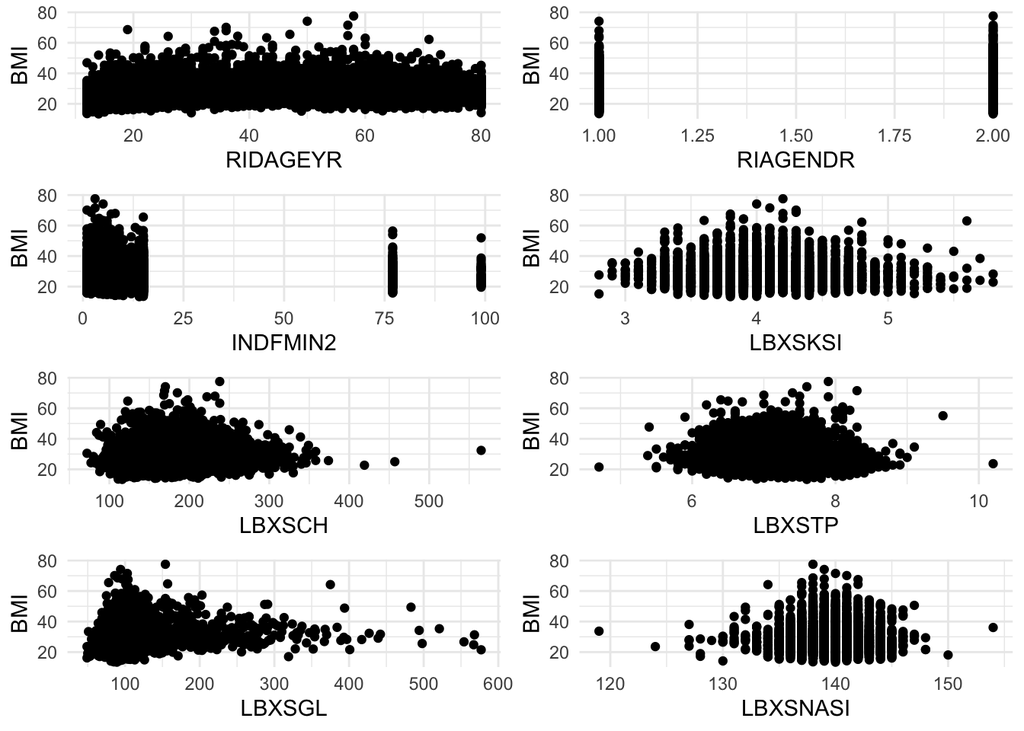

```r
# EDA plots
library(ggplot2)
#install.packages("gridExtra")
library(gridExtra)

plots_list <- list()
# dot plot to gain insight and data trend from each independent variable and the original BMI dependent variable
numeric_vars <- names(data)[sapply(data, is.numeric) & names(data) != "BMXBMI"]
for (var in numeric_vars) {
    p <- ggplot(data, aes_string(x = var, y = "BMXBMI")) +
        geom_point() +
        labs(x = var, y = "BMI") +
        theme_minimal()
    plots_list[[var]] <- p
}
do.call(grid.arrange, c(plots_list, ncol = 2))
```

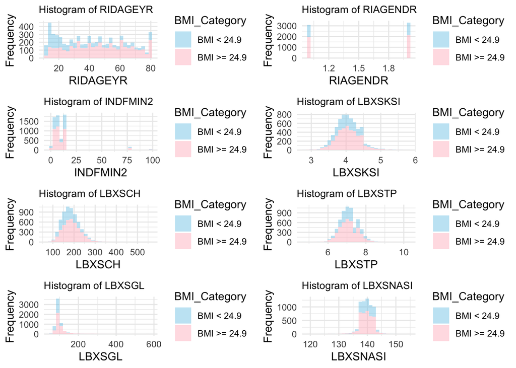

```r
# Histograms to inspect distribution of indenependent variables from overweight and non-overweight individuals
library(dplyr)
data_overweight <- data %>%
  filter(BMXBMI >= 24.9) %>%
  mutate(BMI_Category = "BMI >= 24.9")
data_normal <- data %>%
  filter(BMXBMI < 24.9) %>%
  mutate(BMI_Category = "BMI < 24.9")
combined_data <- rbind(data_overweight, data_normal)

generate_histograms <- function(data) {
  plots_list <- list()
  vars <- names(data)[sapply(data, is.numeric)&names(data) != "BMXBMI"]
  for (var in vars) {
    p <- ggplot(data, aes_string(x = var, fill = "BMI_Category")) +
      geom_histogram( alpha = 0.5, bins = 30) +
      scale_fill_manual(values = c("skyblue", "pink")) +
      labs(x = var, y = "Frequency", title = paste("Histogram of", var)) +
      theme_minimal()+
      theme(plot.title = element_text(size = 10))
    plots_list[[var]] <- p
  }
  return(plots_list)
}
combined_histograms <- generate_histograms(combined_data)
do.call(grid.arrange, c(combined_histograms, ncol = 2))
```

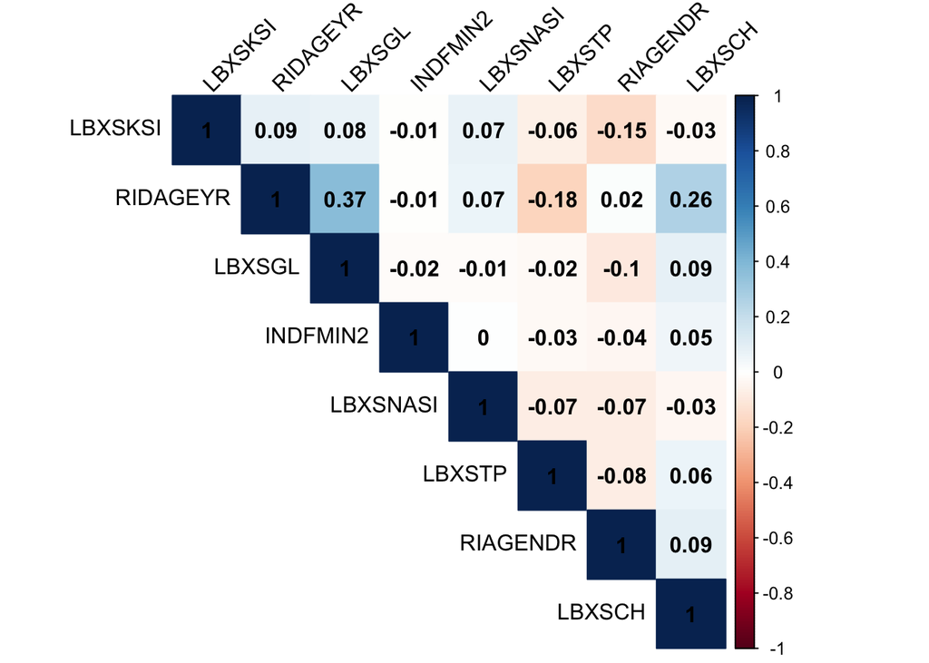

```r
# correlation and collinearity (Spearman)
# To ensure there is no significant correlation between independent variables
correlation_matrix <- cor(data[, -ncol(data)], method="spearman")
library(corrplot)
corrplot(correlation_matrix, method = "color", addCoef.col = "black", type = "upper", order = "hclust", tl.col="black", tl.srt=45)
```

```r
# scaling the predictor variables
features <- data[setdiff(names(data), 'BMXBMI')]
target_variable <- data['BMXBMI']
features_numeric <- as.data.frame(lapply(features, function(x) if(is.factor(x)) as.numeric(as.character(x)) else x))
features_scaled <- scale(features_numeric)
data_scaled <- cbind(features_scaled, target_variable)
```

Rubric 3:

Hypothesis test

Null hypothesis: there is no significant difference in mean BMI between the two genders. Alternative hypothesis: there is a significant difference in mean BMI between the two genders.

t-test: assumptions: We do believe the sampling is random, and our sample is normal distributed

F-test: P value of our F test is 8.21755e-28 which is significantly smaller than 0.05, so we reject the null hypothesis that the male and female have equal variances in bmi.

The t test p value is 8.745e-09 and is smaller than 0.05, so we reject the null hypothesis that there is no significant difference in mean BMI between the two genders.

```r
male_data <- data[data$RIAGENDR == 1, "BMXBMI"]
female_data <- data[data$RIAGENDR == 2, "BMXBMI"]
variance_test_result <- var.test(male_data, female_data)
print(variance_test_result$p.value)
```

```
## [1] 8.21755e-28
```

```r
t_test_result <- t.test(male_data, female_data)
print(t_test_result)
```

```
##
##  Welch Two Sample t-test
##
## data:  male_data and female_data
## t = -5.7612, df = 6300, p-value = 8.745e-09
## alternative hypothesis: true difference in means is not equal to 0
## 95 percent confidence interval:
##  -1.3882218 -0.6833418
## sample estimates:
## mean of x mean of y
##  27.70517  28.74095
```

Rubric 4-5: We chose decision tree as our model. Since there is no strong linear correlation between our dependent and independent variables, we select a non-parametric model: tree. We discard income and potassium because of their minimal correlation coefficients (<0.1) with outcome variables.

```r
# add the y label (overweight status) to our dataset
data$y <- ifelse(data$BMXBMI <= 24.9, 0, 1)
set.seed(715)
#inspect correlation to make sure no collinearity and select variables based on correlation
cor_matrix<- cor(data)
print(cor_matrix)
```

```
##              RIDAGEYR    RIAGENDR      INDFMIN2      LBXSKSI      LBXSCH
## RIDAGEYR  1.000000000  0.01708662  0.0091371164  0.108514823  0.23829311
## RIAGENDR  0.017086620  1.00000000 -0.0244265523 -0.143308571  0.09359380
## INDFMIN2  0.009137116 -0.02442655  1.0000000000  0.011470590  0.01021806
## LBXSKSI   0.108514823 -0.14330857  0.0114705898  1.000000000 -0.03448987
## LBXSCH    0.238293108  0.09359380  0.0102180611 -0.034489874  1.00000000
## LBXSTP   -0.177050707 -0.07289131  0.0086069164 -0.067848965  0.06225671
## LBXSGL    0.256743409 -0.03980419 -0.0104317299  0.058890479  0.04638710
## LBXSNASI  0.041093847 -0.06290800  0.0013406901  0.073401633 -0.03212273
## BMXBMI    0.187032354  0.07137940 -0.0341736000  0.009581918  0.09446352
## y         0.248534474 -0.01269028  0.0003343026  0.005385607  0.14771030
##                LBXSTP      LBXSGL    LBXSNASI       BMXBMI             y
## RIDAGEYR -0.177050707  0.25674341  0.04109385  0.187032354  0.2485344742
## RIAGENDR -0.072891308 -0.03980419 -0.06290800  0.071379396 -0.0126902773
## INDFMIN2  0.008606916 -0.01043173  0.00134069 -0.034173600  0.0003343026
## LBXSKSI  -0.067848965  0.05889048  0.07340163  0.009581918  0.0053856065
## LBXSCH    0.062256707  0.04638710 -0.03212273  0.094463520  0.1477102968
## LBXSTP    1.000000000 -0.02020185 -0.05943089 -0.036397979 -0.0515587822
## LBXSGL   -0.020201848  1.00000000 -0.18625047  0.195170590  0.1772661936
## LBXSNASI -0.059430887 -0.18625047  1.00000000 -0.039485187 -0.0277730161
## BMXBMI   -0.036397979  0.19517059 -0.03948519  1.000000000  0.6896576028
## y        -0.051558782  0.17726619 -0.02777302  0.689657603  1.0000000000
```

```r
#split data into train test split
split_index <- sample(1:nrow(data), 0.8 * nrow(data))

#Variable selection by not selecting INDFMIN2, LBXSKSI

X_train <- data[split_index, c("RIDAGEYR", "RIAGENDR", "LBXSCH", "LBXSTP", "LBXSGL", "LBXSNASI")]
y_train <- data[split_index, "y"]

X_test <- data[-split_index, c("RIDAGEYR", "RIAGENDR","LBXSCH", "LBXSTP", "LBXSGL", "LBXSNASI")]
y_test <- data[-split_index, "y"]
# inspect data imbalance
percentage_of_1 <- mean(y_train == 1) * 100
print(percentage_of_1)
```

```
## [1] 63.17231
```

```r
percentage_of_1 <- mean(y_test == 1) * 100
print(percentage_of_1)
```

```
## [1] 65.12901
```

```r
library(tree)
tree_model <- tree(y_train ~ ., data = X_train)
```

Rubric 6: Evaluate model fit on our training dataset To better cater to the goal of our model-correctly classify individuals, we chose to display our ROC curve, which shows all thresholds of our decision tree.

```r
library(caret)
library(pROC)
predictions <- predict(tree_model, newdata = X_train)
# calculate raw accuracy as a refenrence
binary_predictions <- as.numeric(ifelse(predictions >= 0.5, 1, 0))
confusion_matrix <- confusionMatrix(factor(binary_predictions), factor(y_train))
print(confusion_matrix)
```

```
## Confusion Matrix and Statistics
##
##           Reference
## Prediction    0    1
##          0  848  511
##          1 1035 2719
##
##                Accuracy : 0.6976
##                  95% CI : (0.6848, 0.7102)
##     No Information Rate : 0.6317
##     P-Value [Acc > NIR] : < 2.2e-16
##
##                   Kappa : 0.3101
##
##  Mcnemar's Test P-Value : < 2.2e-16
##
##             Sensitivity : 0.4503
##             Specificity : 0.8418
##          Pos Pred Value : 0.6240
##          Neg Pred Value : 0.7243
##              Prevalence : 0.3683
##          Detection Rate : 0.1659
##    Detection Prevalence : 0.2658
##       Balanced Accuracy : 0.6461
##
##        'Positive' Class : 0
##
```

```r
accuracy <- confusion_matrix$overall["Accuracy"]
print(paste("Accuracy:", accuracy))
```

```
## [1] "Accuracy: 0.697633483277919"
```

```r
# draw roc curves and calculate auc
roc_curve <- roc(y_train, as.numeric(predictions))
auc_value <- auc(roc_curve)
print(paste("AUC:", auc_value))
```

```
## [1] "AUC: 0.705823491595817"
```

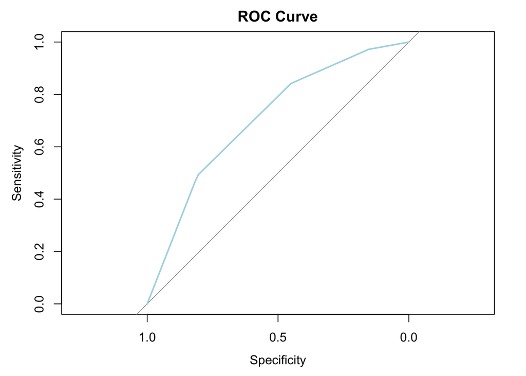

```r
plot(roc_curve, main = "ROC Curve", col = "lightblue", lwd = 2)
```

```r
X_train_d <- data[split_index, c("RIDAGEYR", "RIAGENDR", "INDFMIN2")]

X_test_d <- data[-split_index, c("RIDAGEYR", "RIAGENDR", "INDFMIN2")]

tree_model_d <- tree(y_train ~ ., data = X_train_d)
predictions_d <- predict(tree_model_d, newdata = X_train_d)

binary_predictions_d <- as.numeric(ifelse(predictions_d >= 0.5, 1, 0))
confusion_matrix_d <- confusionMatrix(factor(binary_predictions_d), factor(y_train))
accuracy_d <- confusion_matrix_d$overall["Accuracy"]
print(paste("Demographic Accuracy:", accuracy_d))
```

```
## [1] "Demographic Accuracy: 0.685703109720321"
```

Rubric 8: Conduct one follow-up analysis Part 1: we test our accuracy, roc, and AUC on our test dataset and we observe no overfit in this case.

```r
predictions <- predict(tree_model, newdata = X_test)

binary_predictions <- as.numeric(ifelse(predictions >= 0.5, 1, 0))
confusion_matrix <- confusionMatrix(factor(binary_predictions), factor(y_test))
print(confusion_matrix)
```

```
## Confusion Matrix and Statistics
##
##           Reference
## Prediction   0   1
##          0 191 128
##          1 255 705
##
##                Accuracy : 0.7005
##                  95% CI : (0.6746, 0.7256)
##     No Information Rate : 0.6513
##     P-Value [Acc > NIR] : 0.0001043
##
##                   Kappa : 0.294
##
##  Mcnemar's Test P-Value : 1.208e-10
##
##             Sensitivity : 0.4283
##             Specificity : 0.8463
##          Pos Pred Value : 0.5987
##          Neg Pred Value : 0.7344
##              Prevalence : 0.3487
##          Detection Rate : 0.1493
##    Detection Prevalence : 0.2494
##       Balanced Accuracy : 0.6373
##
##        'Positive' Class : 0
##
```

```r
accuracy <- confusion_matrix$overall["Accuracy"]
print(paste("Accuracy:", accuracy))
```

```
## [1] "Accuracy: 0.700547302580141"
```

```r
roc_curve <- roc(y_test, as.numeric(predictions))
auc_value <- auc(roc_curve)
print(paste("AUC:", auc_value))
```

```
## [1] "AUC: 0.68644587879995"
```

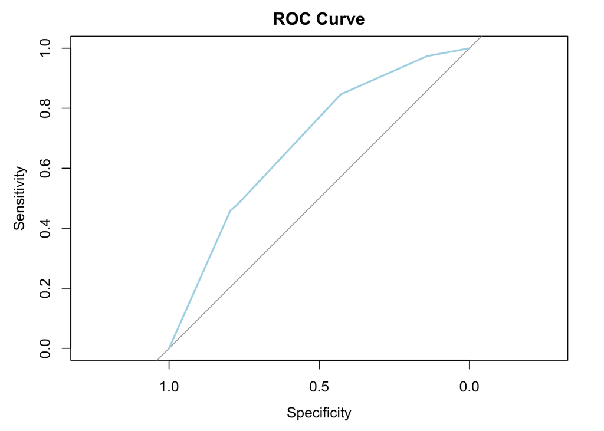

```r
plot(roc_curve, main = "ROC Curve", col = "lightblue", lwd = 2)
```

```r
# add all variables to the train test sets
X_train <- data[split_index, c("RIDAGEYR", "RIAGENDR", "INDFMIN2","LBXSKSI", "LBXSCH", "LBXSTP", "LBXSGL", "LBXSNASI")]

X_test <- data[-split_index, c("RIDAGEYR", "RIAGENDR", "INDFMIN2","LBXSKSI", "LBXSCH", "LBXSTP", "LBXSGL", "LBXSNASI")]

# A tree with gini as classification critera
tree_model_gini <- tree(y_train ~ ., data = X_train, split = "gini")
predictions_g <- predict(tree_model_gini, newdata = X_train)

binary_predictions_g <- as.numeric(ifelse(predictions_g >= 0.5, 1, 0))
confusion_matrix_g <- confusionMatrix(factor(binary_predictions_g), factor(y_train))
accuracy_g <- confusion_matrix_g$overall["Accuracy"]
print(paste("Train Accuracy:", accuracy_g))
```

```
## [1] "Train Accuracy: 0.849794641110894"
```

```r
roc_curve <- roc(y_train, as.numeric(predictions_g))
auc_value <- auc(roc_curve)
print(paste("Train AUC:", auc_value))
```

```
## [1] "Train AUC: 0.935846970367094"
```

```r
predictions_g <- predict(tree_model_gini, newdata = X_test)
binary_predictions_g <- as.numeric(ifelse(predictions_g >= 0.5, 1, 0))
confusion_matrix_g <- confusionMatrix(factor(binary_predictions_g), factor(y_test))
accuracy_g <- confusion_matrix_g$overall["Accuracy"]
print(paste("Test Accuracy:", accuracy_g))
```

```
## [1] "Test Accuracy: 0.614542611415168"
```

```r
roc_curve <- roc(y_test, as.numeric(predictions_g))
auc_value <- auc(roc_curve)
print(paste("Test AUC:", auc_value))
```

```
## [1] "Test AUC: 0.622977890707853"
```